# Agglomerative Clustering

## **What is Agglomerative Clustering?**

Agglomerative clustering is an **unsupervised machine learning technique** used to group similar data points into clusters. It follows a **bottom-up approach**, where each data point starts in its own cluster, and the closest clusters are merged step-by-step. The result of this clustering method is a **dendrogram**, a tree-like diagram that illustrates how the data points are merged into clusters. This technique is particularly useful for uncovering a **hierarchical structure** in the data and gaining a deeper understanding of its underlying patterns.

## **Key Components of Agglomerative Clustering**

### 1. Distance or Similarity Metric

The distance or similarity metric quantifies how similar or dissimilar two data points or clusters are. Common metrics include:

- **Euclidean Distance**: For two points $x$ and $y$ in an $n$-dimensional space, the distance $d(x, y)$ is defined as: $$ d(x, y) = \sqrt{\sum_{i=1}^{n} (x_i - y_i)^2} $$
- **Manhattan Distance**: For the same points $x$ and $y$, the distance $d(x, y)$ is defined as: $$ d(x, y) = \sum_{i=1}^{n} |x_i - y_i| $$
- **Cosine Similarity**: For two vectors $x$ and $y$, the similarity is defined as: $$ \text{similarity}(x, y) = \frac{x \cdot y}{\| x \| \| y \|} $$ where $x \cdot y$ is the dot product of $x$ and $y$, and $\| x \|$ and $\| y \|$ are their norms.

### 2. Linkage Criteria

Linkage criteria determine how the distance between clusters is calculated, impacting the cluster shapes and sizes. Common linkage methods include:

- **Single Linkage**: The distance between two clusters $S$ and $T$ is defined as: $$ d(S, T) = \min_{x \in S, y \in T} d(x, y) $$
- **Complete Linkage**: The distance between two clusters $S$ and $T$ is defined as: $$ d(S, T) = \max_{x \in S, y \in T} d(x, y) $$
- **Average Linkage**: The distance between two clusters $S$ and $T$ is defined as: $$ d(S, T) = \frac{1}{|S| |T|} \sum_{x \in S} \sum_{y \in T} d(x, y) $$
- **Ward’s Method**: The distance between two clusters $S$ and $T$ is defined as the increase in variance when they are merged: $$ \Delta \text{Var}(S, T) = \frac{|S| |T|}{|S| + |T|} d(\bar{x}_S, \bar{x}_T)^2 $$ where $\bar{x}_S$ and $\bar{x}_T$ are the centroids of clusters $S$ and $T$, respectively, and $d$ is the distance between the centroids.

### 3. Cluster Initialization

Initially, each data point is treated as a separate cluster. If there are $N$ data points, there are $N$ initial clusters:

$$ C_i = \{ x_i \}, \quad i = 1, 2, \dots, N $$

## 4. Dendrogram

The dendrogram is a visual representation showing the multi-level hierarchy of clusters formed. It records the distances at which clusters merge, typically visualized vertically.

## 5. Termination Criterion

The algorithm stops based on a predefined condition, such as:

- A specific number of clusters is reached.
- The distance between the nearest clusters exceeds a threshold.

## **Algorithmic Steps in Agglomerative Clustering**

### 1. **Initialization**

- Each data point is treated as its own cluster. If there are **N** data points, we start with **N** clusters.

### 2. **Compute Proximity**

- Calculate the distance between every pair of clusters using a distance metric. Common metrics include:
  - **Euclidean distance**: Suitable for geometric shapes.
  - **Manhattan distance**: Used for grid-like distances.
  - **Cosine similarity**: Commonly used for text data or high-dimensional datasets.

### 3. **Merge Clusters**

- Identify the two closest clusters and merge them into a single cluster.
- This reduces the total number of clusters by one.

### 4. **Update Distance Matrix**

- After merging, update the distance matrix to reflect the distance between the new cluster and all remaining clusters.
- Linkage methods determine how the distance between clusters is calculated:
  - **Single Linkage**: Defined as the shortest distance between any member of one cluster and any member of the other.
  - **Complete Linkage**: Defined as the longest distance between any member of one cluster and any member of the other.
  - **Average Linkage**: The average distance between all pairs of members from both clusters.
  - **Ward’s Method**: The increase in the total within-cluster variance when two clusters merge.

### 5. **Repeat**

- Repeat the merging process until all data points form a single cluster or until the desired number of clusters is reached.

### 6. **Assess the clustering using silhoutte scores**

- Silhouette Score: This is a method to assess how well the clusters are formed. It measures how similar each point is to its own cluster compared to other clusters. The silhouette score ranges from -1 (poor clustering) to +1 (good clustering).

Note: It’s important to calculate the silhouette score after completing clustering to evaluate the quality of the clustering result.

### 7. **Dendrogram Construction**

- As clusters are merged, a **dendrogram** is created. This diagram shows how data points are grouped into clusters.
- By cutting the dendrogram at a specific distance, you can decide on the number of clusters that best represent the data.

## **Pros of Agglomerative Clustering**

### 1. **Intuitive and Easy to Understand**

- The algorithm is simple and intuitive, progressively merging the closest pairs of clusters.
- The **dendrogram** helps visualize the process, making it easy to interpret and understand.

### 2. **Flexible Linkage Methods**

- The algorithm allows you to choose different **linkage methods** (e.g., **single**, **complete**, **average**, or **Ward’s**) to fit the specific structure of your data.

### 3. **No Need to Specify Cluster Number Initially**

- Unlike **k-means**, **agglomerative clustering** does not require you to specify the number of clusters beforehand.
- The number of clusters can be determined by analyzing the dendrogram and cutting it at the desired level.

### 4. **Can Handle Non-Elliptical Shapes**

- Agglomerative clustering is capable of identifying clusters with **non-elliptical shapes**, unlike centroid-based methods like **k-means** that assume spherical clusters.
- This makes it ideal for complex datasets with irregular cluster shapes.

### 5. **Robust to Noise and Outliers**

- By choosing appropriate linkage methods (like **complete** or **average linkage**), the algorithm can be more robust to **noise** and **outliers**, avoiding their negative impact on clustering.

## **Cons of Agglomerative Clustering**

### 1. **Computational Complexity**

- Agglomerative clustering is computationally expensive, particularly for large datasets.
- The **time complexity** is **O(N³)**, and the **space complexity** is **O(N²)**, where **N** is the number of data points.
- This makes it less suitable for large-scale datasets.

### 2. **Irreversible Steps**

- Once a **merging decision** is made, it cannot be undone without restarting the algorithm.
- Poor early merge decisions can lead to **sub-optimal clustering** since there is no way to backtrack or correct mistakes.

### 3. **Sensitive to Linkage Criteria**

- The choice of **linkage method** can significantly affect the results of clustering.
- **Single linkage**, in particular, can result in a **chaining effect**, where clusters are linked together inappropriately, leading to less meaningful clusters.

### 4. **Difficulty in Handling Different Sized Clusters and Variances**

- Agglomerative clustering struggles when clusters have very different **sizes**, **numbers of samples**, or **variances**.
- Methods like **single linkage** may perform poorly in such cases, causing the algorithm to miss important cluster structure.

### 5. **No Global Objective**

- Unlike **k-means**, which optimizes a global objective function, agglomerative clustering makes **local decisions**.
- This can sometimes lead to **less cohesive clusters** and prevent the discovery of a **globally optimal structure**.

## **Applications of Agglomerative Clustering**

Agglomerative clustering is widely used across various domains, particularly where hierarchical relationships in the data are important. Key applications include:

1. **Customer Segmentation**: Grouping customers based on purchasing behavior, demographics, or other features.
2. **Image Segmentation**: Dividing an image into segments that represent different regions or objects.
3. **Document Clustering**: Grouping similar documents or articles based on content or keywords.
4. **Anomaly Detection**: Identifying outliers or anomalies in the data, such as fraud detection or network security.
5. **Gene Expression Analysis**: Grouping genes with similar expression patterns in biological research.

Links:

https://dl.acm.org/doi/abs/10.1145/3322645.3322677 \ https://ieeexplore.ieee.org/abstract/document/1044838

https://www.emerald.com/insight/content/doi/10.1108/eb026764/full/html

https://link.springer.com/chapter/10.1007/978-981-13-1056-0_48

https://www.pnas.org/doi/abs/10.1073/pnas.132656399

# Available Packages and Methods for Agglomerative Clustering

Several Python packages provide implementations of Agglomerative Clustering:

### 1. Scikit-learn

- Implements AgglomerativeClustering class.
- Supports different linkage methods (ward, complete, average, single).
- Allows specifying the number of clusters.

### 2. SciPy

- Provides linkage() for hierarchical clustering.
- Used to generate dendrograms.
- Does not directly allow predicting new data.

### 3. HDBSCAN

- Implements hierarchical density-based clustering.
- Automatically determines the number of clusters.
- Not a traditional Agglomerative Clustering algorithm.

## Choice of Package: scikit-learn

For this implementation, we choose scikit-learn due to the following reasons:

- Easy integration with other ML tools: Works seamlessly with scikit-learn pipelines.
- Multiple Linkage Methods: Provides ward, complete, average, and single linkages for different use cases.
- Better Scalability: Optimized for large datasets compared to SciPy, which is more visualization-focused.
- Direct Prediction Capability: Allows fitting and assigning cluster labels directly.

Additionally, SciPy is used for dendrogram visualization, as scikit-learn does not provide built-in hierarchical visualization.

# Basic Example of Agglomerative Clustering

## 1. Load the necessary packages and create data

We will be using the make blobs function present in the sklearn library to create synthetic data to demonstrate our basic example of agglomerative clustering.

```python
import numpy as np
import matplotlib.pyplot as plt
import seaborn as sns
from sklearn.cluster import AgglomerativeClustering
from sklearn.metrics import silhouette_score, make_scorer
from sklearn.datasets import make_blobs
from sklearn.model_selection import GridSearchCV
from scipy.cluster.hierarchy import dendrogram, linkage
from scipy.spatial.distance import pdist

sns.set(style="whitegrid")

X, _ = make_blobs(n_samples=300, centers=4, cluster_std=1.8, random_state=42)  # Increased std for overlap
```

## 2. Plotting the data

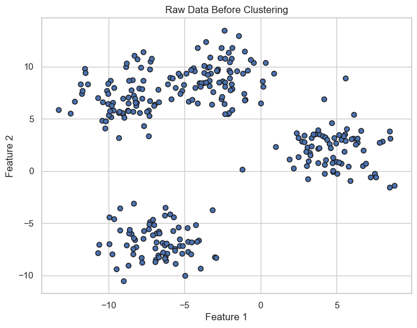

```python
plt.figure(figsize=(8, 6))
plt.scatter(X[:, 0], X[:, 1], edgecolors='k')
plt.title("Raw Data Before Clustering")
plt.xlabel("Feature 1")
plt.ylabel("Feature 2")
plt.show()
```

## 3. Fitting the model

When the agglomerative clustering model is fit without defining any parameters, it fits the data into 2 clusters by default and uses ward linkage method. This is not always the optimal result that we want.

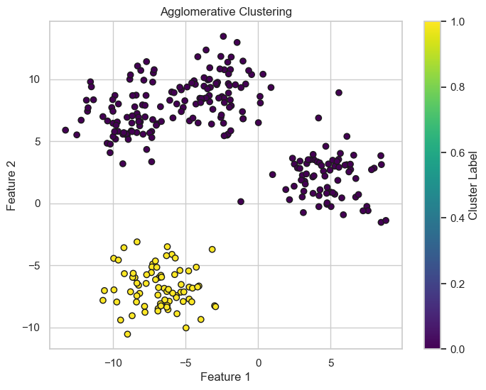

```
Silhouette Score: 0.5363797544001071
```

```python
model = AgglomerativeClustering()
pred = model.fit_predict(X)

score = silhouette_score(X, pred)

plt.figure(figsize=(8, 6))
plt.scatter(X[:, 0], X[:, 1], c=pred, cmap='viridis', edgecolors='k')
plt.title('Agglomerative Clustering')
plt.xlabel("Feature 1")
plt.ylabel("Feature 2")
plt.colorbar(label="Cluster Label")
plt.show()

print('')
print('Silhouette Score:', score)
```

## 3. Performing hyperparamter tuning

Unlike supervised learning models, Agglomerative Clustering is an unsupervised algorithm, meaning it does not have predefined labels (y_true) for evaluation. GridSearchCV is primarily designed for supervised learning, where it splits data into training and validation sets and evaluates model performance using metrics like accuracy or RMSE. However, since Agglomerative Clustering does not have a predict() method, GridSearchCV cannot directly evaluate clustering quality. Instead, we must assess clustering using an unsupervised metric, such as the Silhouette Score, which measures how well-separated the clusters are.

To tune hyperparameters (n_clusters and linkage method), we implemented manual hyperparameter tuning by iterating through a predefined grid of parameter values. For each combination of n_clusters (3 to 6) and linkage methods (ward, complete, average), we fitted an AgglomerativeClustering model, assigned cluster labels, and computed the Silhouette Score. The best-performing model was selected based on the highest Silhouette Score, ensuring optimal separation between clusters. This manual tuning approach effectively replaces GridSearchCV, allowing us to optimize clustering performance in an unsupervised setting.

```python
n_clusters_options = [3, 4, 5, 6]
linkage_options = ['ward', 'complete', 'average']

best_score = -1
best_params = None
best_labels = None

for n_clusters in n_clusters_options:
    for linkage_method in linkage_options:
        # Fit Agglomerative Clustering
        clustering = AgglomerativeClustering(n_clusters=n_clusters, linkage=linkage_method)
        labels = clustering.fit_predict(X)

        # Compute silhouette score
        score = silhouette_score(X, labels)
        print(f"Clusters: {n_clusters}, Linkage: {linkage_method}, Silhouette Score: {score:.4f}")

        # Save best model
        if score > best_score:
            best_score = score
            best_params = {'n_clusters': n_clusters, 'linkage': linkage_method}
            best_labels = labels
```

```
Clusters: 3, Linkage: ward, Silhouette Score: 0.6674
Clusters: 3, Linkage: complete, Silhouette Score: 0.6674
Clusters: 3, Linkage: average, Silhouette Score: 0.6653
Clusters: 4, Linkage: ward, Silhouette Score: 0.6330
Clusters: 4, Linkage: complete, Silhouette Score: 0.6229
Clusters: 4, Linkage: average, Silhouette Score: 0.5566
Clusters: 5, Linkage: ward, Silhouette Score: 0.5662
Clusters: 5, Linkage: complete, Silhouette Score: 0.5149
Clusters: 5, Linkage: average, Silhouette Score: 0.5578
Clusters: 6, Linkage: ward, Silhouette Score: 0.4699
Clusters: 6, Linkage: complete, Silhouette Score: 0.5316
Clusters: 6, Linkage: average, Silhouette Score: 0.5170
```

```python
print(f"\nBest Parameters: {best_params}")
print(f"Best Silhouette Score: {best_score:.4f}")
```

```
Best Parameters: {'n_clusters': 3, 'linkage': 'ward'}
Best Silhouette Score: 0.6674
```

## 4. Plotting the clusters

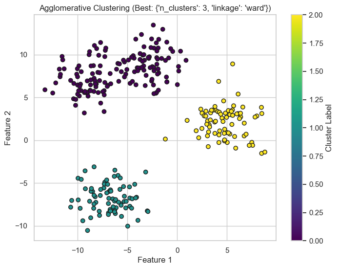

```python
def plot_clusters(X, labels, title):
    plt.figure(figsize=(8, 6))
    plt.scatter(X[:, 0], X[:, 1], c=labels, cmap='viridis', edgecolors='k')
    plt.title(title)
    plt.xlabel("Feature 1")
    plt.ylabel("Feature 2")
    plt.colorbar(label="Cluster Label")
    plt.show()

plot_clusters(X, best_labels, title=f"Agglomerative Clustering (Best: {best_params})")
```

## 5. Plotting the Dendogram

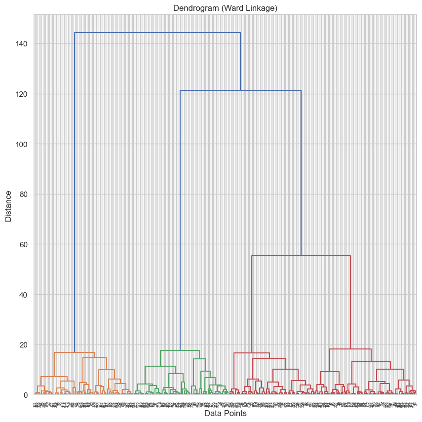

```python
def plot_dendrogram(X, linkage_method):
    plt.figure(figsize=(10, 10))

    if linkage_method == 'ward':
        linked = linkage(X, method='ward')
    else:
        linked = linkage(pdist(X), method=linkage_method)

    dendrogram(linked, truncate_mode='level', p=10)
    plt.title(f"Dendrogram ({linkage_method.capitalize()} Linkage)")
    plt.xlabel("Data Points")
    plt.ylabel("Distance")
    plt.show()

plot_dendrogram(X, linkage_method=best_params['linkage'])
```

# Real World Example: Chicago Airbnb Listings

## Loading the dataset

```python
import pandas as pd
df = pd.read_csv('listings.csv')
```

## Exploratory Data Analysis

```python
df.head()
```

|  | id | listing_url | scrape_id | last_scraped | source | name | description | neighborhood_overview | picture_url | host_id | ... | review_scores_communication | review_scores_location | review_scores_value | license | instant_bookable | calculated_host_listings_count | calculated_host_listings_count_entire_homes | calculated_host_listings_count_private_rooms | calculated_host_listings_count_shared_rooms | reviews_per_month |
| --- | --- | --- | --- | --- | --- | --- | --- | --- | --- | --- | --- | --- | --- | --- | --- | --- | --- | --- | --- | --- | --- |
| 0 | 2396340 | https://www.airbnb.com/rooms/2396340 | 20241218025114 | 2024-12-18 | city scrape | The Woodsman's Gallery at OHC - No Cleaning Fee! | Welcome to Open House Contemporary! Chicago's ... | River West is the perfect place to call home b... | https://a0.muscache.com/pictures/monet/Select-... | 5228189 | ... | 4.98 | 4.82 | 4.81 | 2385048 | f | 21 | 21 | 0 | 0 | 4.08 |
| 1 | 2437230 | https://www.airbnb.com/rooms/2437230 | 20241218025114 | 2024-12-18 | city scrape | City Hideaway | This is a first floor, private apartment in th... | Chicago is a city of neighborhoods. This home... | https://a0.muscache.com/pictures/ce2daacb-38f2... | 7000138 | ... | 4.96 | 4.96 | 4.80 | R24000114939 | f | 1 | 1 | 0 | 0 | 0.83 |
| 2 | 2479175 | https://www.airbnb.com/rooms/2479175 | 20241218025114 | 2024-12-18 | city scrape | Cozy Garden-Subterranean Apartment | Our cozy Lincoln Square one bedroom apartment ... | This is the Lincoln Square Neighborhood in Chi... | https://a0.muscache.com/pictures/miso/Hosting-... | 12681444 | ... | 4.98 | 4.91 | 4.78 | R17000017830 | f | 1 | 1 | 0 | 0 | 2.23 |
| 3 | 2499596 | https://www.airbnb.com/rooms/2499596 | 20241218025114 | 2024-12-18 | city scrape | Vintage Apartment in the Heart of the Ukrainia... | The flat is full of restored original oak wood... | The apartment is in the Ukrainian Village, off... | https://a0.muscache.com/pictures/ff835c68-3bd6... | 2768314 | ... | 4.88 | 4.88 | 4.75 | R23000108359 | f | 3 | 3 | 0 | 0 | 1.45 |
| 4 | 2515629 | https://www.airbnb.com/rooms/2515629 | 20241218025114 | 2024-12-18 | city scrape | Cozy, Quiet, Private bathroom in private room | Room for rent. Has outer room with microwave,... | So close to everything. Downtown, parks and f... | https://a0.muscache.com/pictures/miso/Hosting-... | 12877384 | ... | 4.93 | 4.38 | 4.83 | R21000073422 | f | 2 | 1 | 1 | 0 | 1.46 |

5 rows × 75 columns

```python
df.info()
df.isnull().sum()
```

```
<class 'pandas.core.frame.DataFrame'>
RangeIndex: 8691 entries, 0 to 8690
Data columns (total 75 columns):
 #   Column                                        Non-Null Count  Dtype
---  ------                                        --------------  -----
 0   id                                            8691 non-null   int64
 1   listing_url                                   8691 non-null   object
 2   scrape_id                                     8691 non-null   int64
 3   last_scraped                                  8691 non-null   object
 4   source                                        8691 non-null   object
 5   name                                          8691 non-null   object
 6   description                                   8516 non-null   object
 7   neighborhood_overview                         5410 non-null   object
 8   picture_url                                   8691 non-null   object
 9   host_id                                       8691 non-null   int64
```

[output cut: 67 more lines]

```
id                                                 0
listing_url                                        0
scrape_id                                          0
last_scraped                                       0
source                                             0
                                                ...
calculated_host_listings_count                     0
calculated_host_listings_count_entire_homes        0
calculated_host_listings_count_private_rooms       0
calculated_host_listings_count_shared_rooms        0
reviews_per_month                               1783
Length: 75, dtype: int64
```

```python
df_subset = df[['latitude', 'longitude', 'price', 'room_type', 'review_scores_rating', 'number_of_reviews']]
df_subset.head()
```

|  | latitude | longitude | price | room_type | review_scores_rating | number_of_reviews |
| --- | --- | --- | --- | --- | --- | --- |
| 0 | 41.89634 | -87.65608 | $178.00 | Entire home/apt | 4.90 | 534 |
| 1 | 41.94272 | -87.68409 | $228.00 | Entire home/apt | 4.92 | 107 |
| 2 | 41.96316 | -87.69208 | $88.00 | Entire home/apt | 4.79 | 289 |
| 3 | 41.90006 | -87.68096 | $135.00 | Entire home/apt | 4.80 | 190 |
| 4 | 41.88152 | -87.69768 | $36.00 | Private room | 4.77 | 185 |

```python
df_subset.loc[:, 'price'] = df_subset['price'].replace('[\$,]', '', regex=True).astype(float)
df_subset.head()
```

|  | latitude | longitude | price | room_type | review_scores_rating | number_of_reviews |
| --- | --- | --- | --- | --- | --- | --- |
| 0 | 41.89634 | -87.65608 | 178.0 | Entire home/apt | 4.90 | 534 |
| 1 | 41.94272 | -87.68409 | 228.0 | Entire home/apt | 4.92 | 107 |
| 2 | 41.96316 | -87.69208 | 88.0 | Entire home/apt | 4.79 | 289 |
| 3 | 41.90006 | -87.68096 | 135.0 | Entire home/apt | 4.80 | 190 |
| 4 | 41.88152 | -87.69768 | 36.0 | Private room | 4.77 | 185 |

```python
df_subset.isnull().sum()
```

```
latitude                   0
longitude                  0
price                    427
room_type                  0
review_scores_rating    1783
number_of_reviews          0
dtype: int64
```

```python
df_subset = df_subset.dropna(subset=['price'])

median_rating = df_subset['review_scores_rating'].median()
df_subset.loc[:,'review_scores_rating'] = df_subset['review_scores_rating'].fillna(median_rating)

df_subset.isnull().sum()
```

```
latitude                0
longitude               0
price                   0
room_type               0
review_scores_rating    0
number_of_reviews       0
dtype: int64
```

### Encoding Room Type (Categorical Feature)

```python
from sklearn.preprocessing import LabelEncoder

le = LabelEncoder()
df_subset['room_type_encoded'] = le.fit_transform(df_subset['room_type'])
df_subset = df_subset.drop(columns=['room_type'])

df_subset.head()
```

|  | latitude | longitude | price | review_scores_rating | number_of_reviews | room_type_encoded |
| --- | --- | --- | --- | --- | --- | --- |
| 0 | 41.89634 | -87.65608 | 178.0 | 4.90 | 534 | 0 |
| 1 | 41.94272 | -87.68409 | 228.0 | 4.92 | 107 | 0 |
| 2 | 41.96316 | -87.69208 | 88.0 | 4.79 | 289 | 0 |
| 3 | 41.90006 | -87.68096 | 135.0 | 4.80 | 190 | 0 |
| 4 | 41.88152 | -87.69768 | 36.0 | 4.77 | 185 | 2 |

```python
room_type_mapping = dict(zip(le.classes_, le.transform(le.classes_)))
print(room_type_mapping)
```

```
{'Entire home/apt': 0, 'Hotel room': 1, 'Private room': 2, 'Shared room': 3}
```

#### Mapping Results:

1. Entire Home: 0
2. Hotel Room: 1
3. Private Room: 2
4. Share Room: 3

### Normalizing the variables

```python
from sklearn.preprocessing import StandardScaler
scaler = StandardScaler()

columns_to_scale = ['latitude', 'longitude', 'price', 'review_scores_rating', 'number_of_reviews', 'room_type_encoded']
df_scaled = scaler.fit_transform(df_subset[columns_to_scale])
df_scaled = pd.DataFrame(df_scaled, columns=columns_to_scale)

df_scaled.head()
```

|  | latitude | longitude | price | review_scores_rating | number_of_reviews | room_type_encoded |
| --- | --- | --- | --- | --- | --- | --- |
| 0 | 0.080371 | 0.134269 | -0.007350 | 0.348459 | 5.465866 | -0.544044 |
| 1 | 0.824500 | -0.514385 | 0.043937 | 0.406517 | 0.615597 | -0.544044 |
| 2 | 1.152443 | -0.699417 | -0.099667 | 0.029145 | 2.682925 | -0.544044 |
| 3 | 0.140055 | -0.441901 | -0.051457 | 0.058173 | 1.558389 | -0.544044 |
| 4 | -0.157404 | -0.829101 | -0.153005 | -0.028913 | 1.501595 | 1.804952 |

## Agglomerative Clustering

```python
from sklearn.cluster import AgglomerativeClustering

agg_clustering = AgglomerativeClustering(n_clusters=4, linkage='ward')
df_scaled['cluster'] = agg_clustering.fit_predict(df_scaled)
df_scaled.head()
```

|  | latitude | longitude | price | review_scores_rating | number_of_reviews | room_type_encoded | cluster |
| --- | --- | --- | --- | --- | --- | --- | --- |
| 0 | 0.080371 | 0.134269 | -0.007350 | 0.348459 | 5.465866 | -0.544044 | 1 |
| 1 | 0.824500 | -0.514385 | 0.043937 | 0.406517 | 0.615597 | -0.544044 | 1 |
| 2 | 1.152443 | -0.699417 | -0.099667 | 0.029145 | 2.682925 | -0.544044 | 1 |
| 3 | 0.140055 | -0.441901 | -0.051457 | 0.058173 | 1.558389 | -0.544044 | 1 |
| 4 | -0.157404 | -0.829101 | -0.153005 | -0.028913 | 1.501595 | 1.804952 | 0 |

### Visualizing the clusters

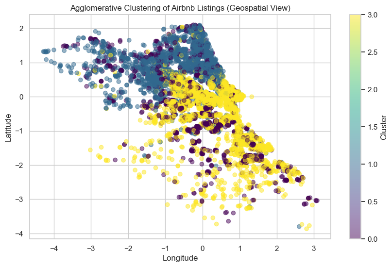

```python
import matplotlib.pyplot as plt

plt.figure(figsize=(10, 6))
plt.scatter(df_scaled['longitude'], df_scaled['latitude'], c=df_scaled['cluster'], cmap='viridis', alpha=0.5)

plt.xlabel("Longitude")
plt.ylabel("Latitude")
plt.title("Agglomerative Clustering of Airbnb Listings (Geospatial View)")
plt.colorbar(label="Cluster")

plt.show()
```

```python
df_subset['cluster'] = df_scaled['cluster']

cluster_summary = df_subset.groupby('cluster').mean()
cluster_summary
```

| cluster | latitude | longitude | price | review_scores_rating | number_of_reviews | room_type_encoded |
| --- | --- | --- | --- | --- | --- | --- |
| 0.0 | 41.889655 | -87.659702 | 182.785757 | 4.779234 | 53.842730 | 0.440356 |
| 1.0 | 41.894947 | -87.664132 | 200.007928 | 4.786332 | 76.358152 | 0.483626 |
| 2.0 | 41.977320 | -87.764590 | 65.0 | 4.700000 | 10.000000 | 0.000000 |
| 3.0 | 41.890617 | -87.662147 | 178.771666 | 4.769050 | 37.922557 | 0.434849 |

```python
df_subset['cluster'].value_counts()
```

```
cluster
3.0    3254
1.0    2901
0.0    1685
2.0       1
Name: count, dtype: int64
```

```python
import pandas as pd

# Group by cluster and compute mean values
cluster_summary = df_subset.groupby('cluster').mean()

# Display results
import ace_tools_open as tools
tools.display_dataframe_to_user(name="Cluster Summary", dataframe=cluster_summary)
```

```
Cluster Summary
```

longitude

price

review_scores_rating

number_of_reviews

room_type_encoded

cluster

[figure not shown]

## Refining the clusters

### Using a Dendrogram to Find the Optimal Number of Clusters

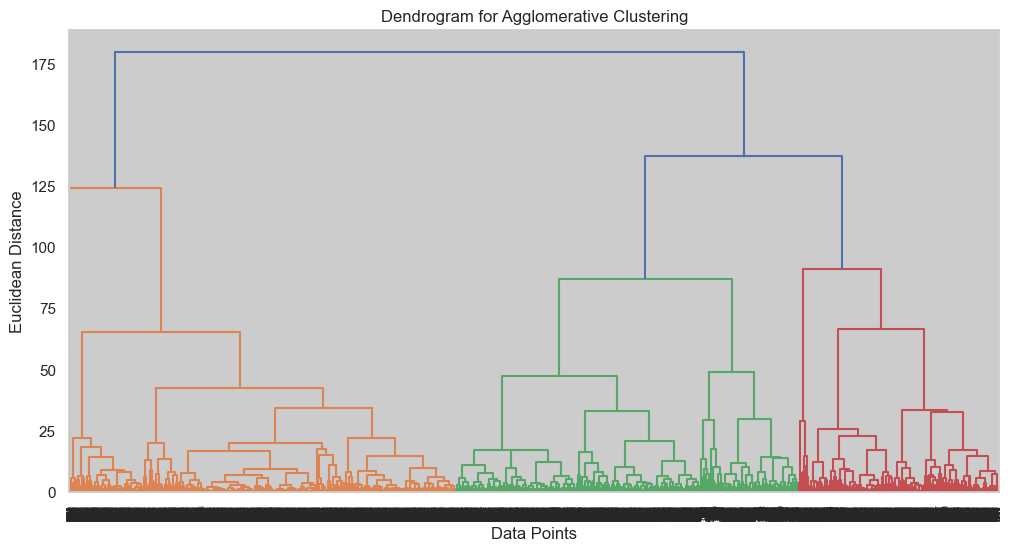

```python
import scipy.cluster.hierarchy as sch
import matplotlib.pyplot as plt

# Plot dendrogram
plt.figure(figsize=(12, 6))
dendrogram = sch.dendrogram(sch.linkage(df_scaled, method='ward'))
plt.title("Dendrogram for Agglomerative Clustering")
plt.xlabel("Data Points")
plt.ylabel("Euclidean Distance")
plt.show()
```

### Initialising with 5 clusters

```python
from sklearn.cluster import AgglomerativeClustering

# Apply Agglomerative Clustering with 5 clusters
agg_clustering = AgglomerativeClustering(n_clusters=5, linkage='ward')
df_scaled['cluster'] = agg_clustering.fit_predict(df_scaled)
df_subset['cluster'] = df_scaled['cluster']

df_subset['cluster'].value_counts()
```

```
cluster
1.0    3254
0.0    2901
2.0    1599
4.0      86
3.0       1
Name: count, dtype: int64
```

```python
# Show details of the listing in Cluster 3
df_subset[df_subset['cluster'] == 3]
```

|  | latitude | longitude | price | review_scores_rating | number_of_reviews | room_type_encoded | cluster |
| --- | --- | --- | --- | --- | --- | --- | --- |
| 905 | 41.97732 | -87.76459 | 65.0 | 4.7 | 10 | 0 | 3.0 |

#### Inference: Assuming that this was an outlier, we remove it from our dataset.

```python
df_subset = df_subset[df_subset['cluster'] != 3]
```

## Initialising with 3 clusters

```python
from sklearn.cluster import AgglomerativeClustering

# Apply Agglomerative Clustering with clusters
agg_clustering = AgglomerativeClustering(n_clusters=3, linkage='ward')
df_scaled['cluster'] = agg_clustering.fit_predict(df_scaled)
df_subset['cluster'] = df_scaled['cluster']

df_subset['cluster'].value_counts()
```

```
cluster
0.0    3254
2.0    2901
1.0    1685
Name: count, dtype: int64
```

```python
cluster_summary = df_subset.groupby('cluster').mean()

# Display cluster insights
import ace_tools_open as tools
tools.display_dataframe_to_user(name="Cluster Summary", dataframe=cluster_summary)
```

```
Cluster Summary
```

longitude

price

review_scores_rating

number_of_reviews

room_type_encoded

cluster

[figure not shown]

### Visualizing the clusters

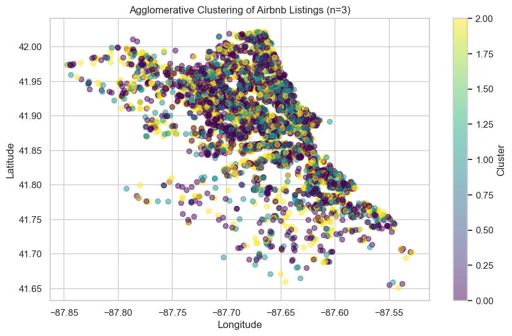

```python
import matplotlib.pyplot as plt

# Scatter plot of latitude vs. longitude, colored by cluster
plt.figure(figsize=(10, 6))
plt.scatter(df_subset['longitude'], df_subset['latitude'], c=df_subset['cluster'], cmap='viridis', alpha=0.5)

# Labels and title
plt.xlabel("Longitude")
plt.ylabel("Latitude")
plt.title("Agglomerative Clustering of Airbnb Listings (n=3)")
plt.colorbar(label="Cluster")

# Show plot
plt.show()
```

## Making price categories

```python
import numpy as np

low_price_threshold = np.percentile(df_subset['price'], 33)
high_price_threshold = np.percentile(df_subset['price'], 66)

df_subset['price_category'] = np.where(df_subset['price'] <= low_price_threshold, 'Low',
                                       np.where(df_subset['price'] <= high_price_threshold, 'Mid', 'High'))

df_subset[['price', 'price_category']].head()
```

|  | price | price_category |
| --- | --- | --- |
| 0 | 178.0 | High |
| 1 | 228.0 | High |
| 2 | 88.0 | Low |
| 3 | 135.0 | Mid |
| 4 | 36.0 | Low |

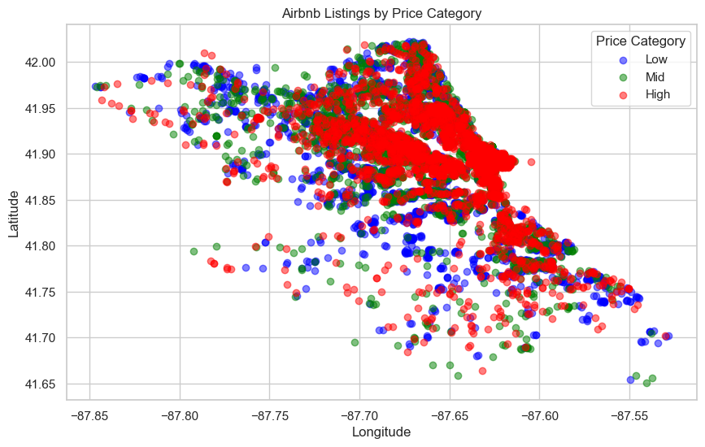

```python
import matplotlib.pyplot as plt

# Assign colors to price categories
color_map = {'Low': 'blue', 'Mid': 'green', 'High': 'red'}

# Create scatter plot
plt.figure(figsize=(10, 6))
for category, color in color_map.items():
    subset = df_subset[df_subset['price_category'] == category]
    plt.scatter(subset['longitude'], subset['latitude'], label=category, color=color, alpha=0.5)

# Labels and title
plt.xlabel("Longitude")
plt.ylabel("Latitude")
plt.title("Airbnb Listings by Price Category")
plt.legend(title="Price Category")
plt.show()
```

### Observations

1. High-Priced Listings (Red) Dominate the Central Area
- The central region has a dense concentration of expensive listings. This suggests high demand or prime locations (downtown or tourist areas).
1. Mid & Low-Priced Listings (Green & Blue) Are More Scattered
- They appear in outer areas or less dense regions. This could indicate budget-friendly neighborhoods or suburban listings.
- Some Areas Have a Mix of All Price Ranges
1. Certain areas have all three price categories, meaning both budget and luxury options exist in the same neighborhoods.

# Requirements to Run Agglomerative Clustering

## 1. Operating System Compatibility

### The model runs on:

1. Windows 10/11
2. macOS Monterey or later
3. Ubuntu 20.04+ (or any Linux distribution with Python support)

## 2. Python Version

### Recommended: Python 3.9+ (Tested on Python 3.11.9)

# **Agglomerative Clustering - Requirements**

## **1. Operating System Compatibility**

The model runs on:

- **Windows 10/11**
- **macOS Monterey or later**
- **Ubuntu 20.04+ (or any Linux distribution with Python support)**

## **2. Python Version**

- Recommended: **Python 3.9+** (Tested on **Python 3.11.9**)
- Ensure Python is installed and added to the system **PATH**.

## **3. Required Python Packages**

To perform **Agglomerative Clustering**, install the following Python packages:

- **numpy** → Numerical operations
- **pandas** → Data manipulation
- **matplotlib** → Visualization
- **seaborn** → Enhanced visualizations
- **scikit-learn** → Machine learning (Agglomerative Clustering)
- **scipy** → Dendrogram visualization
- **geopandas** → Geospatial data handling
- **shapely** → Geometric operations
- **folium** → Interactive geospatial mapping
- **Jupyter Notebook** → If using Jupyter for interactive analysis
- **from sklearn.cluster** import AgglomerativeClustering

## **4. Installation Commands**

Install all required dependencies using: ```sh pip install numpy pandas matplotlib seaborn scikit-learn scipy geopandas shapely folium jupyter